# NMDS

Kate

December 23, 2018

### Community composition by severity

**Small mammal community varied across fire severities.** The NMDS plot shows variation in community composition of small mammals, standardized by trapping effort. NMDS was performed on on Bray-Curtis distances in three dimensions (stress = 0.09). Each circle represents a site, with the standard deviation of the centroids for each fire severity represented as color-coded ellipses (n = 9 for each). Community composition was significantly different between fire severity treatments (Adonis F(2,24) = 4.39, R<sup>2</sup> = 0.268, p = 0.003). Post-hoc analysis by pairwise Adonis showed that community composition in unburned sites and high severity sites was significantly different (pairwise p = 0.006).

- Species codes:
  - SPBE = California ground squirrel
  - GLSA = northern flying squirrel
  - TAAM = yellow-pine chipmunk
  - TAQU = long-eared chipmunk
  - TASE = shadow chipmunk
  - NEFU = dusky-footed woodrat
  - PEMA = North American deer mouse
  - PEBO = brush mouse
  - PETR = Pinyon mouse
  - REME = western harvest mouse
  - SOTR = Trowbridge’s shrew
- Considered using ANOSIM instead of Adonis, but Adonis is more robust because it is less sensitive to dispersion (also used betadisper to determine that dispersion was similar across treatments in order to satisfy assumptions of Adonis)
- Pairwise Adonis for moderate severity vs. high severity gave borderline p-value (p < 0.05 or p > 0.5 based on permutation)
- Ordination looked similar for both raw data and data adjusted for trapping effort
- Used three dimensions for NMDS in order to reduce stress (according to scree plot) and to avoid local minima (2 dimension nmds returned two solutions)

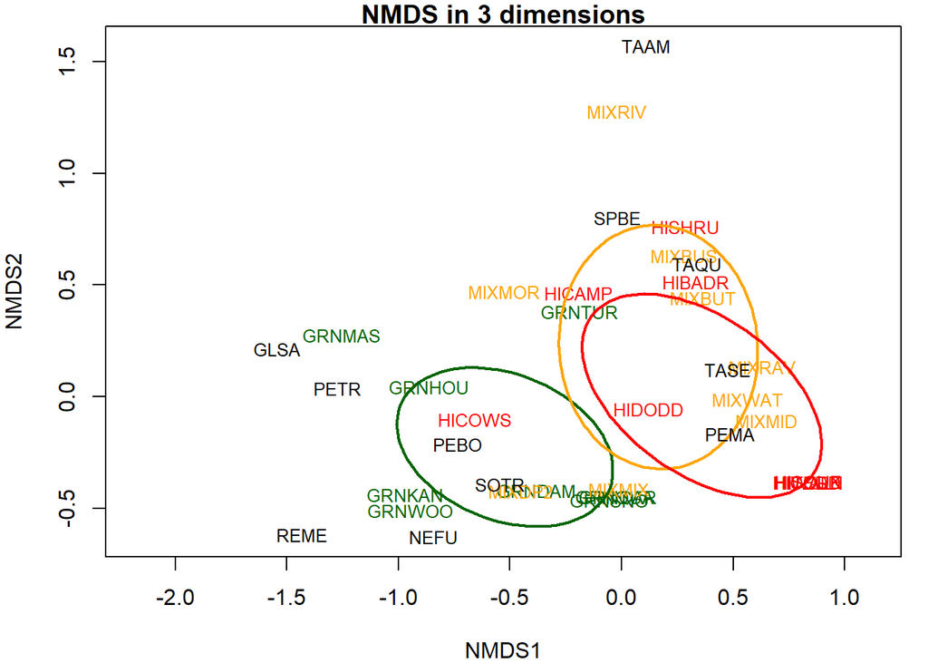

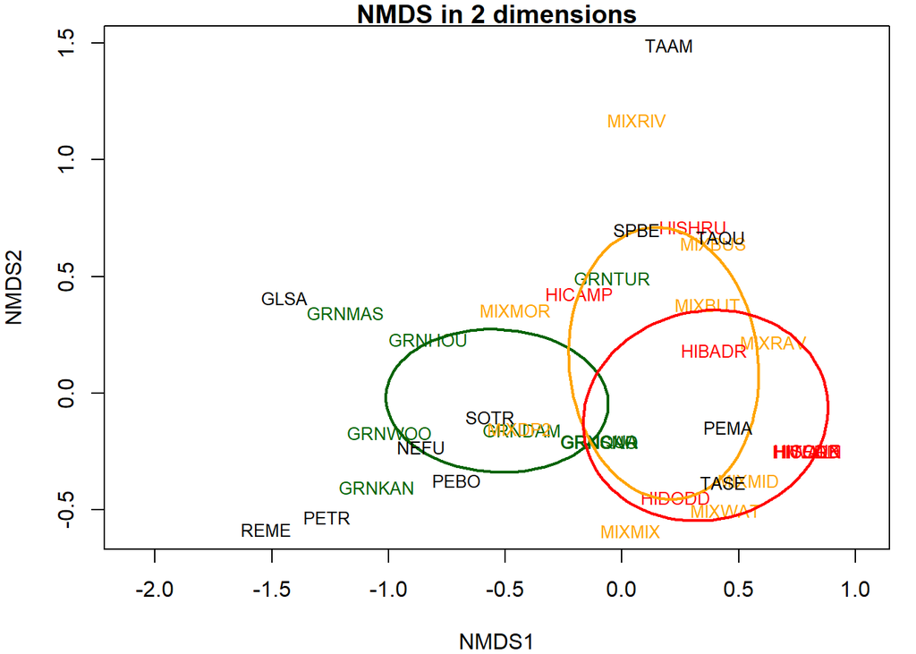

### Habitat drivers of community composition

**Habitat drivers of small mammal communities.** The NMDS plot shows variation in community composition of small mammals, standardized by trapping effort. NMDS was performed on on Bray-Curtis distances in three dimensions (stress = 0.09). Each circle represents a site, with the standard deviation of the centroids for each fire severity represented as color-coded ellipses (n = 9 for each). Arrows represent the relative contributions of several possible habitat variables. Community composition was significantly different between fire severity treatments (Adonis F(2,24) = 4.39, R<sup>2</sup> = 0.268, p = 0.003). Post-hoc analysis by pairwise Adonis showed that community composition in unburned sites and high severity sites was significantly different (pairwise p = 0.006).

- Appears to be fewer sites because some of them exactly overlap
- Habitat variables:
  - tree_bm
  - shrub_bm
  - grass_bm
  - forb_bm
  - tree_density
  - tree_survival
  - veg_cover
  - litter_cover
  - cwd_volume
  - tree_H
  - shrub_H
  - forb_H

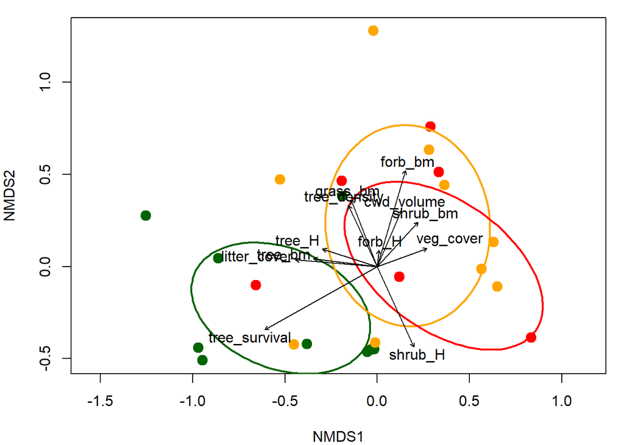